# Mini Project (Unsupervised Learning)

# Principal Component Analysis of Wine Data

## Steps involved

PCA involves following broad level steps –

```
1. Standardize the d-dimensional dataset.
2. Construct the covariance matrix.
3. Decompose the covariance matrix into its eigenvectors and eigenvalues.
4. Select k eigenvectors that correspond to the k largest eigenvalues, where k is the dimensionality of the new   feature subspace (k≤d)
5. Construct a projection matrix W from the "top" k eigenvectors.
6. Transform the d-dimensional input dataset x using the projection matrix W to obtain the new k-dimensional feature subspace
```

```python
# Import the modules
%matplotlib inline
import pandas as pd
import numpy as np
import matplotlib.pyplot as plt
import seaborn as sns

from sklearn.preprocessing import StandardScaler
from sklearn.decomposition import PCA
from scipy.stats import zscore
```

```python
# Read the dataset
dataset = pd.read_csv("https://archive.ics.uci.edu/ml/machine-learning-databases/wine/wine.data", header=None)
```

```python
# Descriptive analytics
print("Shape of the dataset: ", dataset.shape)
dataset.columns = ['class', 'alcohol', 'malic_acid', 'ash', 'alcalinity_ash',
                  'magnesium', 'total_phenol', 'flavanoids', 'nonflavanoid_phenols',
                  'proanthocyanins', 'color_intensity', 'hue', 'diluted_wines',
                  'proline']
```

```
Shape of the dataset:  (178, 14)
```

```python
# Displaying the top 5 rows of the dataset
dataset.head(5)
```

|  | class | alcohol | malic_acid | ash | alcalinity_ash | magnesium | total_phenol | flavanoids | nonflavanoid_phenols | proanthocyanins | color_intensity | hue | diluted_wines | proline |
| --- | --- | --- | --- | --- | --- | --- | --- | --- | --- | --- | --- | --- | --- | --- |
| 0 | 1 | 14.23 | 1.71 | 2.43 | 15.6 | 127 | 2.80 | 3.06 | 0.28 | 2.29 | 5.64 | 1.04 | 3.92 | 1065 |
| 1 | 1 | 13.20 | 1.78 | 2.14 | 11.2 | 100 | 2.65 | 2.76 | 0.26 | 1.28 | 4.38 | 1.05 | 3.40 | 1050 |
| 2 | 1 | 13.16 | 2.36 | 2.67 | 18.6 | 101 | 2.80 | 3.24 | 0.30 | 2.81 | 5.68 | 1.03 | 3.17 | 1185 |
| 3 | 1 | 14.37 | 1.95 | 2.50 | 16.8 | 113 | 3.85 | 3.49 | 0.24 | 2.18 | 7.80 | 0.86 | 3.45 | 1480 |
| 4 | 1 | 13.24 | 2.59 | 2.87 | 21.0 | 118 | 2.80 | 2.69 | 0.39 | 1.82 | 4.32 | 1.04 | 2.93 | 735 |

```python
# Check for null values
dataset.isnull().values.sum()
```

```
0
```

### Attribute definition

1st attribute is **class identifier (1-3)**. Other attributes are below:

1. Alcohol
2. Malic acid
3. Ash
4. Alcalinity of ash
5. Magnesium
6. Total phenols
7. Flavanoids
8. Nonflavanoid phenols
9. Proanthocyanins
10. Color intensity
11. Hue
12. OD280/OD315 of diluted wines
13. Proline

So we will consider 13 attributes for PCA.

```python
# Excluding first attribute
X = dataset.iloc[:, 1:].values
```

### Standardizing the 13-dimensional dataset

We will use the `StandardScaler` class from `sklearn.preprocessing` library to standardize the dataset.

```python
# Standardize the dataset
sc_X = StandardScaler()
X_std = sc_X.fit_transform(X)
X_std.shape
```

```
(178, 13)
```

```python
# Display the standardized dataset
X_std[:3, :]
```

```
array([[ 1.51861254, -0.5622498 ,  0.23205254, -1.16959318,  1.91390522,
         0.80899739,  1.03481896, -0.65956311,  1.22488398,  0.25171685,
         0.36217728,  1.84791957,  1.01300893],
       [ 0.24628963, -0.49941338, -0.82799632, -2.49084714,  0.01814502,
         0.56864766,  0.73362894, -0.82071924, -0.54472099, -0.29332133,
         0.40605066,  1.1134493 ,  0.96524152],
       [ 0.19687903,  0.02123125,  1.10933436, -0.2687382 ,  0.08835836,
         0.80899739,  1.21553297, -0.49840699,  2.13596773,  0.26901965,
         0.31830389,  0.78858745,  1.39514818]])
```

### Constructing the covariance matrix

We will use `cov` function from `numpy` module to find the covariance matrix.

```python
cov_matrix = np.cov(X_std.transpose())
cov_matrix
```

```
array([[ 1.00564972,  0.09493026,  0.21273976, -0.31198788,  0.27232816,
         0.29073446,  0.23815287, -0.15681042,  0.13747022,  0.549451  ,
        -0.07215255,  0.07275191,  0.64735687],
       [ 0.09493026,  1.00564972,  0.16497228,  0.29013035, -0.05488343,
        -0.3370606 , -0.41332866,  0.29463237, -0.22199334,  0.25039204,
        -0.56446685, -0.37079354, -0.19309537],
       [ 0.21273976,  0.16497228,  1.00564972,  0.44587209,  0.28820583,
         0.12970824,  0.11572743,  0.1872826 ,  0.00970647,  0.2603499 ,
        -0.07508874,  0.00393333,  0.22488969],
       [-0.31198788,  0.29013035,  0.44587209,  1.00564972, -0.0838039 ,
        -0.32292752, -0.353355  ,  0.36396647, -0.19844168,  0.01883781,
        -0.27550299, -0.27833221, -0.44308618],
       [ 0.27232816, -0.05488343,  0.28820583, -0.0838039 ,  1.00564972,
         0.21561254,  0.19688989, -0.25774204,  0.23777643,  0.20107967,
         0.05571118,  0.06637684,  0.39557317],
       [ 0.29073446, -0.3370606 ,  0.12970824, -0.32292752,  0.21561254,
         1.00564972,  0.86944804, -0.45247731,  0.61587304, -0.05544792,
         0.43613151,  0.70390388,  0.50092909],
       [ 0.23815287, -0.41332866,  0.11572743, -0.353355  ,  0.19688989,
         0.86944804,  1.00564972, -0.54093859,  0.65637929, -0.17335329,
         0.54654907,  0.79164133,  0.49698518],
       [-0.15681042,  0.29463237,  0.1872826 ,  0.36396647, -0.25774204,
        -0.45247731, -0.54093859,  1.00564972, -0.36791202,  0.13984265,
        -0.26412347, -0.50611293, -0.31314443],
       [ 0.13747022, -0.22199334,  0.00970647, -0.19844168,  0.23777643,
         0.61587304,  0.65637929, -0.36791202,  1.00564972, -0.02539259,
         0.29721399,  0.52199968,  0.33228346],
       [ 0.549451  ,  0.25039204,  0.2603499 ,  0.01883781,  0.20107967,
        -0.05544792, -0.17335329,  0.13984265, -0.02539259,  1.00564972,
        -0.52476129, -0.43123763,  0.31788599],
       [-0.07215255, -0.56446685, -0.07508874, -0.27550299,  0.05571118,
         0.43613151,  0.54654907, -0.26412347,  0.29721399, -0.52476129,
         1.00564972,  0.56866303,  0.23751782],
       [ 0.07275191, -0.37079354,  0.00393333, -0.27833221,  0.06637684,
         0.70390388,  0.79164133, -0.50611293,  0.52199968, -0.43123763,
         0.56866303,  1.00564972,  0.31452809],
       [ 0.64735687, -0.19309537,  0.22488969, -0.44308618,  0.39557317,
         0.50092909,  0.49698518, -0.31314443,  0.33228346,  0.31788599,
         0.23751782,  0.31452809,  1.00564972]])
```

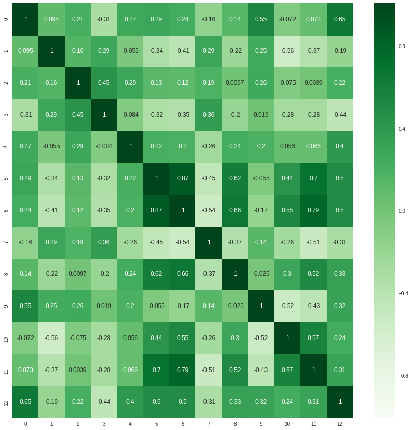

```python
# Print the covariance matrix
plt.figure(figsize=(15, 15))
sns.heatmap(cov_matrix, annot=True, cmap="Greens")
```

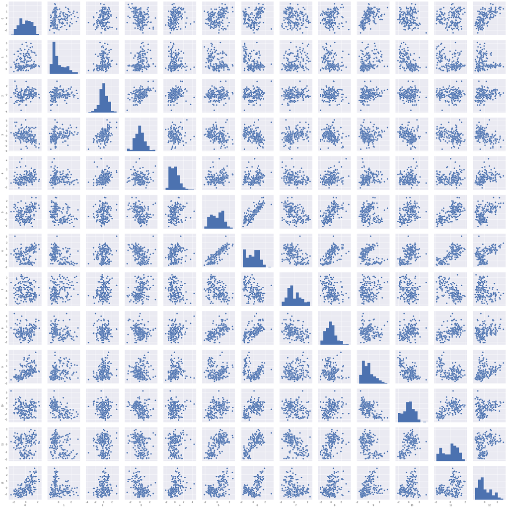

```python
# Pair plot for this dataset
sns.pairplot(pd.DataFrame(X_std))
```

### Decomposing the covariance matrix into its eigenvectors and eigenvalues

To do this we will use `linalg.eig` from `numpy` module.

```python
# Converting to eigen values and eigen vectors
eig_vals, eig_vecs = np.linalg.eig(cov_matrix)
```

```python
eigen_pairs = [(np.abs(eig_vals[i]), eig_vecs[ :, i]) for i in range(len(eig_vals))]

# Sort the (eigenvalue, eigenvector) tuples from high to low
eigen_pairs.sort()
eigen_pairs.reverse()
```

```python
eigen_pairs
```

```
[(4.7324369775835953,
  array([-0.1443294 ,  0.24518758,  0.00205106,  0.23932041, -0.14199204,
         -0.39466085, -0.4229343 ,  0.2985331 , -0.31342949,  0.0886167 ,
         -0.29671456, -0.37616741, -0.28675223])),
 (2.5110809296451233,
  array([ 0.48365155,  0.22493093,  0.31606881, -0.0105905 ,  0.299634  ,
          0.06503951, -0.00335981,  0.02877949,  0.03930172,  0.52999567,
         -0.27923515, -0.16449619,  0.36490283])),
 (1.4542418678464692,
  array([-0.20738262,  0.08901289,  0.6262239 ,  0.61208035,  0.13075693,
          0.14617896,  0.1506819 ,  0.17036816,  0.14945431, -0.13730621,
          0.08522192,  0.16600459, -0.12674592])),
 (0.92416586682487556,
  array([ 0.0178563 , -0.53689028,  0.21417556, -0.06085941,  0.35179658,
         -0.19806835, -0.15229479,  0.20330102, -0.39905653, -0.06592568,
          0.42777141, -0.18412074,  0.23207086])),
 (0.85804867653711181,
  array([-0.26566365,  0.03521363, -0.14302547,  0.06610294,  0.72704851,
         -0.14931841, -0.10902584, -0.50070298,  0.13685982, -0.07643678,
         -0.17361452, -0.10116099, -0.1578688 ])),
 (0.645282212467854,
  array([ 0.21353865,  0.53681385,  0.15447466, -0.10082451,  0.03814394,
         -0.0841223 , -0.01892002, -0.25859401, -0.53379539, -0.41864414,
          0.10598274,  0.26585107,  0.11972557])),
 (0.55414146624578486,
  array([ 0.05639636, -0.42052391,  0.14917061,  0.28696914, -0.3228833 ,
          0.02792498,  0.06068521, -0.59544729, -0.37213935,  0.22771214,
         -0.23207564,  0.0447637 , -0.0768045 ])),
 (0.35046627494625449,
  array([ 0.39613926,  0.06582674, -0.17026002,  0.42797018, -0.15636143,
         -0.40593409, -0.18724536, -0.23328465,  0.36822675, -0.03379692,
          0.43662362, -0.07810789,  0.12002267])),
 (0.29051203269397752,
  array([-0.50861912,  0.07528304,  0.30769445, -0.20044931, -0.27140257,
         -0.28603452, -0.04957849, -0.19550132,  0.20914487, -0.05621752,
         -0.08582839, -0.1372269 ,  0.57578611])),
 (0.25232001036082513,
  array([ 0.21160473, -0.30907994, -0.02712539,  0.05279942,  0.06787022,
         -0.32013135, -0.16315051,  0.21553507,  0.1341839 , -0.29077518,
         -0.52239889,  0.52370587,  0.162116  ])),
 (0.22706428173088539,
  array([-0.22591696,  0.07648554, -0.49869142,  0.47931378,  0.07128891,
          0.30434119, -0.02569409,  0.11689586, -0.23736257,  0.0318388 ,
         -0.04821201,  0.0464233 ,  0.53926983])),
 (0.1697237389801218,
  array([-0.26628645,  0.12169604, -0.04962237, -0.05574287,  0.06222011,
         -0.30388245, -0.04289883,  0.04235219, -0.09555303,  0.60422163,
          0.259214  ,  0.60095872, -0.07940162])),
 (0.10396199182075286,
  array([-0.01496997, -0.02596375,  0.14121803, -0.09168285, -0.05677422,
          0.46390791, -0.83225706, -0.11403985,  0.11691707,  0.0119928 ,
          0.08988884,  0.15671813, -0.01444734]))]
```

```python
# Display the eigen Vectors
print("Eigen Vectors:")
pd.DataFrame(eig_vecs)
```

```
Eigen Vectors:
```

|  | 0 | 1 | 2 | 3 | 4 | 5 | 6 | 7 | 8 | 9 | 10 | 11 | 12 |
| --- | --- | --- | --- | --- | --- | --- | --- | --- | --- | --- | --- | --- | --- |
| 0 | -0.144329 | 0.483652 | -0.207383 | 0.017856 | -0.265664 | 0.213539 | 0.056396 | -0.014970 | 0.396139 | -0.266286 | -0.508619 | -0.225917 | 0.211605 |
| 1 | 0.245188 | 0.224931 | 0.089013 | -0.536890 | 0.035214 | 0.536814 | -0.420524 | -0.025964 | 0.065827 | 0.121696 | 0.075283 | 0.076486 | -0.309080 |
| 2 | 0.002051 | 0.316069 | 0.626224 | 0.214176 | -0.143025 | 0.154475 | 0.149171 | 0.141218 | -0.170260 | -0.049622 | 0.307694 | -0.498691 | -0.027125 |
| 3 | 0.239320 | -0.010591 | 0.612080 | -0.060859 | 0.066103 | -0.100825 | 0.286969 | -0.091683 | 0.427970 | -0.055743 | -0.200449 | 0.479314 | 0.052799 |
| 4 | -0.141992 | 0.299634 | 0.130757 | 0.351797 | 0.727049 | 0.038144 | -0.322883 | -0.056774 | -0.156361 | 0.062220 | -0.271403 | 0.071289 | 0.067870 |
| 5 | -0.394661 | 0.065040 | 0.146179 | -0.198068 | -0.149318 | -0.084122 | 0.027925 | 0.463908 | -0.405934 | -0.303882 | -0.286035 | 0.304341 | -0.320131 |
| 6 | -0.422934 | -0.003360 | 0.150682 | -0.152295 | -0.109026 | -0.018920 | 0.060685 | -0.832257 | -0.187245 | -0.042899 | -0.049578 | -0.025694 | -0.163151 |
| 7 | 0.298533 | 0.028779 | 0.170368 | 0.203301 | -0.500703 | -0.258594 | -0.595447 | -0.114040 | -0.233285 | 0.042352 | -0.195501 | 0.116896 | 0.215535 |
| 8 | -0.313429 | 0.039302 | 0.149454 | -0.399057 | 0.136860 | -0.533795 | -0.372139 | 0.116917 | 0.368227 | -0.095553 | 0.209145 | -0.237363 | 0.134184 |
| 9 | 0.088617 | 0.529996 | -0.137306 | -0.065926 | -0.076437 | -0.418644 | 0.227712 | 0.011993 | -0.033797 | 0.604222 | -0.056218 | 0.031839 | -0.290775 |
| 10 | -0.296715 | -0.279235 | 0.085222 | 0.427771 | -0.173615 | 0.105983 | -0.232076 | 0.089889 | 0.436624 | 0.259214 | -0.085828 | -0.048212 | -0.522399 |
| 11 | -0.376167 | -0.164496 | 0.166005 | -0.184121 | -0.101161 | 0.265851 | 0.044764 | 0.156718 | -0.078108 | 0.600959 | -0.137227 | 0.046423 | 0.523706 |
| 12 | -0.286752 | 0.364903 | -0.126746 | 0.232071 | -0.157869 | 0.119726 | -0.076805 | -0.014447 | 0.120023 | -0.079402 | 0.575786 | 0.539270 | 0.162116 |

```python
# Display the eigen values
print("Eigen Values:")
pd.DataFrame(eig_vals).transpose()
```

```
Eigen Values:
```

|  | 0 | 1 | 2 | 3 | 4 | 5 | 6 | 7 | 8 | 9 | 10 | 11 | 12 |
| --- | --- | --- | --- | --- | --- | --- | --- | --- | --- | --- | --- | --- | --- |
| 0 | 4.732437 | 2.511081 | 1.454242 | 0.924166 | 0.858049 | 0.645282 | 0.554141 | 0.103962 | 0.350466 | 0.169724 | 0.290512 | 0.227064 | 0.25232 |

```python
eig_vecs.shape
```

```
(13, 13)
```

### Selecting k eigenvectors

Select k eigenvectors that correspond to the k largest eigenvalues, where k is the dimensionality of the new feature subspace (k≤d)

```python
tot = sum(eig_vals)
var_exp = [( i /tot ) * 100 for i in sorted(eig_vals, reverse=True)]
cum_var_exp = np.cumsum(var_exp)
print("Cumulative Variance Explained", cum_var_exp)
```

```
Cumulative Variance Explained [  36.1988481    55.40633836   66.52996889   73.59899908   80.16229276
   85.09811607   89.3367954    92.01754435   94.23969775   96.16971684
   97.90655253   99.20478511  100.        ]
```

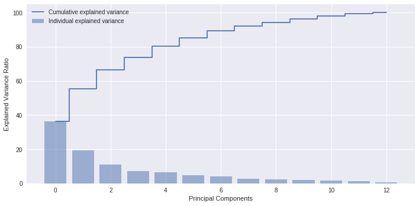

```python
# Ploting
plt.figure(figsize=(10 , 5))
plt.bar(range(13), var_exp, alpha = 0.5, align = 'center', label = 'Individual explained variance')
plt.step(range(13), cum_var_exp, where='mid', label = 'Cumulative explained variance')
plt.ylabel('Explained Variance Ratio')
plt.xlabel('Principal Components')
plt.legend(loc = 'best')
plt.tight_layout()
plt.show()
```

```python
# Select top 7 eigen vectors
eig_vecs_selected = eig_vecs[:, :7]
```

### Insights

Lets select the first 7 eigen vectors which gives us 89.33% coverage of variance from original data.

### Projection matrix W

Constructing a projection matrix W from the "top" 7 eigenvectors.

Here, we are reducing the 13-dimensional feature space to a 7-dimensional feature subspace, by choosing the "top 7" eigenvectors with the highest eigenvalues to construct our d×k-dimensional eigenvector matrix W.

```python
# Projection matrix
W = eig_vecs[:, :7]
```

```python
# Display the eigen Vectors
print("First 7 Eigen Vectors:")
pd.DataFrame(W)
```

```
First 7 Eigen Vectors:
```

|  | 0 | 1 | 2 | 3 | 4 | 5 | 6 |
| --- | --- | --- | --- | --- | --- | --- | --- |
| 0 | -0.144329 | 0.483652 | -0.207383 | 0.017856 | -0.265664 | 0.213539 | 0.056396 |
| 1 | 0.245188 | 0.224931 | 0.089013 | -0.536890 | 0.035214 | 0.536814 | -0.420524 |
| 2 | 0.002051 | 0.316069 | 0.626224 | 0.214176 | -0.143025 | 0.154475 | 0.149171 |
| 3 | 0.239320 | -0.010591 | 0.612080 | -0.060859 | 0.066103 | -0.100825 | 0.286969 |
| 4 | -0.141992 | 0.299634 | 0.130757 | 0.351797 | 0.727049 | 0.038144 | -0.322883 |
| 5 | -0.394661 | 0.065040 | 0.146179 | -0.198068 | -0.149318 | -0.084122 | 0.027925 |
| 6 | -0.422934 | -0.003360 | 0.150682 | -0.152295 | -0.109026 | -0.018920 | 0.060685 |
| 7 | 0.298533 | 0.028779 | 0.170368 | 0.203301 | -0.500703 | -0.258594 | -0.595447 |
| 8 | -0.313429 | 0.039302 | 0.149454 | -0.399057 | 0.136860 | -0.533795 | -0.372139 |
| 9 | 0.088617 | 0.529996 | -0.137306 | -0.065926 | -0.076437 | -0.418644 | 0.227712 |
| 10 | -0.296715 | -0.279235 | 0.085222 | 0.427771 | -0.173615 | 0.105983 | -0.232076 |
| 11 | -0.376167 | -0.164496 | 0.166005 | -0.184121 | -0.101161 | 0.265851 | 0.044764 |
| 12 | -0.286752 | 0.364903 | -0.126746 | 0.232071 | -0.157869 | 0.119726 | -0.076805 |

### Transform the dataset

Transforming the 13-dimensional input dataset x using the projection matrix W to obtain the new 7-dimensional feature subspace.

```python
W.shape
```

```
(13, 7)
```

```python
X_std.shape
```

```
(178, 13)
```

```python
# creating new subspace
new_features = np.dot(X_std, W)
pd.DataFrame(new_features)
```

|  | 0 | 1 | 2 | 3 | 4 | 5 | 6 |
| --- | --- | --- | --- | --- | --- | --- | --- |
| 0 | -3.316751 | 1.443463 | -0.165739 | 0.215631 | 0.693043 | 0.223880 | -0.596427 |
| 1 | -2.209465 | -0.333393 | -2.026457 | 0.291358 | -0.257655 | 0.927120 | -0.053776 |
| 2 | -2.516740 | 1.031151 | 0.982819 | -0.724902 | -0.251033 | -0.549276 | -0.424205 |
| 3 | -3.757066 | 2.756372 | -0.176192 | -0.567983 | -0.311842 | -0.114431 | 0.383337 |
| 4 | -1.008908 | 0.869831 | 2.026688 | 0.409766 | 0.298458 | 0.406520 | -0.444074 |
| 5 | -3.050254 | 2.122401 | -0.629396 | 0.515637 | -0.632019 | -0.123431 | -0.401654 |
| 6 | -2.449090 | 1.174850 | -0.977095 | 0.065831 | -1.027762 | 0.620121 | -0.052891 |
| 7 | -2.059437 | 1.608963 | 0.146282 | 1.192608 | 0.076903 | 1.439806 | -0.032376 |
| 8 | -2.510874 | 0.918071 | -1.770969 | -0.056270 | -0.892257 | 0.129181 | -0.125285 |
| 9 | -2.753628 | 0.789438 | -0.984247 | -0.349382 | -0.468553 | -0.163392 | 0.874352 |
| 10 | -3.479737 | 1.302333 | -0.422735 | -0.026842 | -0.338375 | 0.182902 | -0.248162 |
| 11 | -1.754753 | 0.611977 | -1.190878 | 0.890164 | -0.738573 | 0.553055 | 0.434266 |
| 12 | -2.113462 | 0.675706 | -0.865086 | 0.356438 | -1.209929 | 0.215076 | 0.242597 |
| 13 | -3.458157 | 1.130630 | -1.204276 | -0.162458 | -2.023127 | -0.745781 | -1.475773 |
| 14 | -4.312784 | 2.095976 | -1.263913 | -0.305773 | -1.029693 | -0.795643 | -0.999971 |
| 15 | -2.305188 | 1.662552 | 0.217903 | 1.440590 | -0.469550 | 0.422213 | 0.180968 |
| 16 | -2.171955 | 2.327305 | 0.831730 | 0.912601 | -0.000115 | 0.066529 | -0.109488 |
| 17 | -1.898971 | 1.631369 | 0.794914 | 1.082380 | -0.438705 | -0.364931 | -0.091647 |
| 18 | -3.541985 | 2.518344 | -0.485459 | 0.910323 | -1.153079 | -0.303877 | 0.033464 |
| 19 | -2.084522 | 1.061138 | -0.164747 | -0.484997 | 0.882511 | 1.393018 | 0.102472 |
| 20 | -3.124403 | 0.786897 | -0.364887 | 0.025562 | 0.972414 | 0.106922 | -0.264762 |
| 21 | -1.086570 | 0.241744 | 0.936962 | -1.029910 | 0.315972 | 1.211015 | -0.296932 |
| 22 | -2.535224 | -0.091841 | -0.311933 | 0.048391 | -0.429582 | 1.014943 | 0.127770 |
| 23 | -1.644988 | -0.516279 | 0.143885 | 0.413720 | -0.375720 | 0.784506 | 0.668402 |
| 24 | -1.761576 | -0.317149 | 0.890286 | 0.115116 | -0.556668 | 0.898749 | 0.623551 |
| 25 | -0.990079 | 0.940667 | 3.820908 | 1.321561 | 0.159005 | 0.265128 | -0.481907 |
| 26 | -1.775278 | 0.686175 | -0.086700 | 0.232907 | -1.142943 | 0.571474 | 0.458028 |
| 27 | -1.235424 | -0.089807 | -1.386897 | 0.495683 | -0.375941 | 0.608088 | 0.363010 |
| 28 | -2.188406 | 0.689570 | 1.394567 | 0.777492 | -0.810584 | 0.602072 | -0.117933 |
| 29 | -2.256109 | 0.191462 | -1.092657 | -0.286152 | -0.483073 | 0.335234 | 0.158350 |
| ... | ... | ... | ... | ... | ... | ... | ... |
| 148 | 2.807064 | 1.570534 | -0.472528 | -0.627358 | -0.260173 | -0.553243 | 0.449464 |
| 149 | 2.899659 | 2.041057 | -0.495960 | -0.471156 | 1.438877 | -0.178543 | 0.393520 |
| 150 | 2.320737 | 2.356366 | 0.437682 | 0.052260 | 2.234427 | -0.076779 | 1.273439 |
| 151 | 2.549831 | 2.045283 | -0.312268 | -0.386972 | 1.847523 | -0.980029 | 1.627192 |
| 152 | 1.812541 | 1.527646 | 1.362590 | 0.189396 | 1.749387 | -0.970292 | 1.541851 |
| 153 | 2.760145 | 2.138932 | -0.964629 | -0.668386 | -0.477042 | -1.802113 | -1.018406 |
| 154 | 2.737151 | 0.409886 | -1.190405 | 0.663045 | 0.459037 | -1.881890 | -0.023338 |
| 155 | 3.604869 | 1.802384 | -0.094037 | -1.268840 | -0.609465 | -0.191933 | -1.418423 |
| 156 | 2.889826 | 1.925219 | -0.782323 | -1.324725 | -0.571243 | -0.430606 | -0.217856 |
| 157 | 3.392156 | 1.311876 | 1.602026 | 0.482842 | -0.670871 | -0.803565 | -0.095837 |
| 158 | 1.048182 | 3.515090 | 1.160039 | -0.935329 | -0.899449 | -3.284281 | 0.642463 |
| 159 | 1.609912 | 2.406638 | 0.548560 | -0.754310 | -0.995207 | -2.919477 | 0.711056 |
| 160 | 3.143131 | 0.738161 | -0.090999 | -0.980648 | -0.409814 | -0.398922 | 0.074031 |
| 161 | 2.240157 | 1.175465 | -0.101377 | 1.165279 | -0.264449 | 0.801039 | -0.539883 |
| 162 | 2.847674 | 0.556044 | 0.804215 | 0.897888 | -0.254801 | 0.288568 | -0.867762 |
| 163 | 2.597497 | 0.697966 | -0.884940 | 0.274229 | 0.772235 | 0.719842 | -0.272500 |
| 164 | 2.949299 | 1.555309 | -0.983401 | -0.015480 | -0.364082 | -0.491206 | 0.985935 |
| 165 | 3.530032 | 0.882527 | -0.466029 | -0.580790 | -0.668960 | 0.458814 | -0.522221 |
| 166 | 2.406111 | 2.592356 | 0.428226 | 0.184335 | 0.447661 | -0.569506 | -0.035802 |
| 167 | 2.929085 | 1.274447 | -1.213358 | -0.295316 | -0.267350 | -0.381213 | 0.644321 |
| 168 | 2.181413 | 2.077537 | 0.763783 | 0.389593 | 0.359874 | -0.629568 | 0.753322 |
| 169 | 2.380928 | 2.588667 | 1.418044 | -0.588502 | 1.127997 | 0.983645 | 0.930473 |
| 170 | 3.211617 | -0.251249 | -0.847129 | 0.217065 | 0.609095 | 0.395378 | 0.291849 |
| 171 | 3.677919 | 0.847748 | -1.339420 | 0.125176 | -0.486112 | -0.857959 | 1.025640 |
| 172 | 2.465556 | 2.193798 | -0.918781 | -0.018025 | -0.701210 | -0.680855 | 0.829199 |
| 173 | 3.370524 | 2.216289 | -0.342570 | -1.058527 | -0.574164 | 1.108788 | -0.958416 |
| 174 | 2.601956 | 1.757229 | 0.207581 | -0.349496 | 0.255063 | 0.026465 | -0.146894 |
| 175 | 2.677839 | 2.760899 | -0.940942 | -0.312035 | 1.271355 | -0.273068 | -0.679235 |
| 176 | 2.387017 | 2.297347 | -0.550696 | 0.688285 | 0.813955 | -1.178783 | -0.633975 |
| 177 | 3.208758 | 2.768920 | 1.013914 | -0.596903 | -0.895193 | -0.296092 | -0.005741 |

178 rows × 7 columns

## Conclusion

Using PCA, we were able to reduce the huge 13 dimensional dataset to 7 dimensional subspace, by retaining 89.33% of the variance of the original dataset.

We used 6 steps to apply Principal Component Analysis on our dataset.

This can also accomplished using PCA implementation from scikit-learn. Ex: `from sklearn.decomposition import PCA as sklearnPCA`

## Constructing a classification model

```python
# Importing the libraries
import numpy as np
import matplotlib.pyplot as plt
import pandas as pd

# Importing the dataset
dataset = pd.read_csv("https://archive.ics.uci.edu/ml/machine-learning-databases/wine/wine.data", header=None)
X = dataset.iloc[:, 1:].values
y = dataset.iloc[:, 0].values

# Splitting the dataset into the Training set and Test set
from sklearn.model_selection import train_test_split
X_train, X_test, y_train, y_test = train_test_split(X, y, test_size = 0.25, random_state = 0)

# Feature Scaling
from sklearn.preprocessing import StandardScaler
sc = StandardScaler()
X_train = sc.fit_transform(X_train)
X_test = sc.transform(X_test)

# Applying PCA
from sklearn.decomposition import PCA
pca = PCA(n_components = 2)
X_train = pca.fit_transform(X_train)
X_test = pca.transform(X_test)
explained_variance = pca.explained_variance_ratio_

# Fitting SVM to the Training set
from sklearn.svm import SVC
classifier = SVC(kernel = 'linear', random_state = 0)
classifier.fit(X_train, y_train)

# Predicting the Test set results
y_pred = classifier.predict(X_test)

# Making the Confusion Matrix
from sklearn.metrics import confusion_matrix
cm = confusion_matrix(y_test, y_pred)
```

```python
# Model score
classifier.score(X_test, y_test)
```

```
0.97777777777777775
```

```python
# Explained Variance
explained_variance
```

```
array([ 0.37281068,  0.18739996])
```

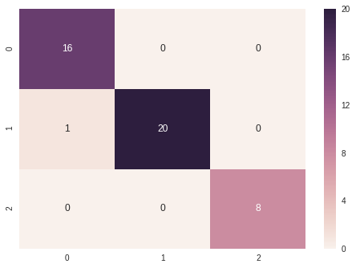

```python
sns.heatmap(cm, annot=True)
```

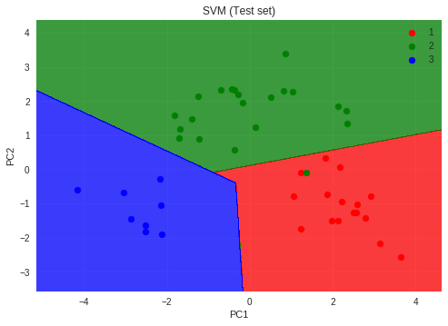

```python
# Visualising the Test set results
from matplotlib.colors import ListedColormap
X_set, y_set = X_test, y_test
X1, X2 = np.meshgrid(np.arange(start = X_set[:, 0].min() - 1, stop = X_set[:, 0].max() + 1, step = 0.01),
                     np.arange(start = X_set[:, 1].min() - 1, stop = X_set[:, 1].max() + 1, step = 0.01))
plt.contourf(X1, X2, classifier.predict(np.array([X1.ravel(), X2.ravel()]).T).reshape(X1.shape),
             alpha = 0.75, cmap = ListedColormap(('red', 'green', 'blue')))
plt.xlim(X1.min(), X1.max())
plt.ylim(X2.min(), X2.max())
for i, j in enumerate(np.unique(y_set)):
    plt.scatter(X_set[y_set == j, 0], X_set[y_set == j, 1],
                c = ListedColormap(('red', 'green', 'blue'))(i), label = j)
plt.title('SVM (Test set)')
plt.xlabel('PC1')
plt.ylabel('PC2')
plt.legend()
plt.show()
```

## Insights

- Using SVM to classify the wine dataset to 3 classes
- Applied PCA and reducing the dimentionality to just 2
- These 2 Principal Components explained total variance of 56.02% of the total variance in the dataset
- The SVM model was able to get a accuracy of 97.77%